# Fenerbahçe Beko EuroLeague Match Analyses

Faculty of Mathematics

Andrija Radojević

# Fenerbahçe Beko EuroLeague Match Statistics

Introduction

I am currently conducting a data analysis project whose primary objective is to develop value models and investigate correlations among key basketball performance parameters in modern sports. The findings will be presented through statistical methods I am familiar with, including visualizations, summary tables, and other relevant forms of interpretation. Basketball is my passion, and the club selected for this study holds particular personal significance, as I have watched many of the games that form part of the analysis. The scope of this project covers the period from 2002 to 2025 within Europe’s premier basketball competition, the EuroLeague. In the sections that follow, I will clearly specify which aspects of the data are being analyzed at each stage.

Data description

The dataset includes the following variables: Date, Opposing_Team, IsHome, Points, Performance_Index_Rating, Two-point%, Three-point%, Free-throw%, Offensive_rebounds, Defensive_rebounds, Total_rebounds, Assists, Steals, Blocks, Turnovers.

Additional variables may be engineered throughout the course of the analysis to enhance the depth and accuracy of the statistical evaluation.

Data loading

```r
#loading dataset and reading first few lines

library(dplyr)
library(data.table)
a<- fread("fenerbahce_beko.csv")

head(a)
```

```
##                 Date Opposing_Team IsHome Points Performance_Index_Rating
##               <char>        <char>  <int>  <num>                    <num>
## 1: 18 Apr 2002 (Thu)   CSKA Moscow      1     96                       88
## 2: 27 Mar 2002 (Wed)  Tau Ceramica      1     72                       64
## 3: 21 Mar 2002 (Thu) Maccabi Elite      1     78                       71
## 4:  6 Mar 2002 (Wed)   CSKA Moscow      0     80                       76
## 5: 27 Feb 2002 (Wed)  Tau Ceramica      0     69                       36
## 6: 13 Feb 2002 (Wed)     Peristeri      1     93                      105
##    Two-point% Three-point% Free-throw% Offensive_rebounds Defensive_rebounds
##        <char>       <char>      <char>              <num>              <num>
## 1:      51.2%        51.9%       80.0%                  5                 13
## 2:      45.0%        44.4%       70.6%                  5                 16
## 3:      50.0%        25.0%       78.1%                 11                 18
## 4:      56.4%        33.3%       65.2%                  9                 24
## 5:      46.8%        18.8%       61.5%                 13                 15
## 6:      51.4%        42.3%       68.8%                 10                 17
##    Total_rebounds Assists Steals Blocks Turnovers
##             <num>   <num>  <num>  <num>     <num>
## 1:             18      22     11      1        11
## 2:             21      19      6      2        12
## 3:             29      10      7      2        12
## 4:             33      15      4      0        15
## 5:             28       9      6      0        17
## 6:             27      21     11      2         7
```

```r
#basic descriptive statistics
summary(a)
```

```
##      Date           Opposing_Team          IsHome           Points
##  Length:629         Length:629         Min.   :0.0000   Min.   : 43.00
##  Class :character   Class :character   1st Qu.:0.0000   1st Qu.: 71.00
##  Mode  :character   Mode  :character   Median :1.0000   Median : 78.00
##                                        Mean   :0.5024   Mean   : 78.57
##                                        3rd Qu.:1.0000   3rd Qu.: 86.00
##                                        Max.   :1.0000   Max.   :118.00
##                                                         NA's   :7
##  Performance_Index_Rating  Two-point%        Three-point%
##  Min.   : 27.00           Length:629         Length:629
##  1st Qu.: 71.00           Class :character   Class :character
##  Median : 86.00           Mode  :character   Mode  :character
##  Mean   : 84.74
##  3rd Qu.:100.00
##  Max.   :155.00
##  NA's   :7
##  Free-throw%        Offensive_rebounds Defensive_rebounds Total_rebounds
##  Length:629         Min.   : 1.000     Min.   :10.00      Min.   :18.00
##  Class :character   1st Qu.: 7.000     1st Qu.:19.00      1st Qu.:28.00
##  Mode  :character   Median : 9.000     Median :22.00      Median :32.00
##                     Mean   : 9.693     Mean   :22.46      Mean   :32.15
##                     3rd Qu.:12.000     3rd Qu.:25.75      3rd Qu.:36.00
##                     Max.   :30.000     Max.   :36.00      Max.   :50.00
##                     NA's   :7          NA's   :7          NA's   :7
##     Assists          Steals           Blocks         Turnovers
##  Min.   : 3.00   Min.   : 0.000   Min.   : 0.000   Min.   : 2.0
##  1st Qu.:12.00   1st Qu.: 5.000   1st Qu.: 1.000   1st Qu.:10.0
##  Median :16.00   Median : 7.000   Median : 2.000   Median :13.0
##  Mean   :15.65   Mean   : 7.006   Mean   : 2.669   Mean   :12.7
##  3rd Qu.:19.00   3rd Qu.: 9.000   3rd Qu.: 4.000   3rd Qu.:15.0
##  Max.   :32.00   Max.   :26.000   Max.   :16.000   Max.   :26.0
##  NA's   :7       NA's   :7        NA's   :7        NA's   :16
```

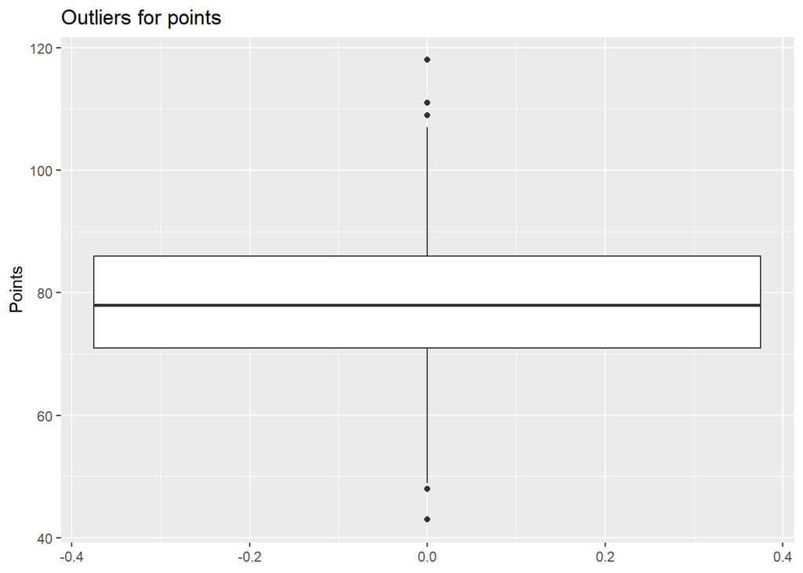

```r
library(ggplot2)

#plot for outliers of points

ggplot(a,aes(y=Points))+
  geom_boxplot()+
  labs(title="Outliers for points")
```

A boxplot was constructed to provide a preliminary overview of the distribution of potential outliers. Identifying these outliers at this stage is essential, as it will inform and guide subsequent statistical analyses.

```r
#sort of all rows and columns with NA

p <- which(is.na(a), arr.ind = TRUE)
p_sort <- p[order(p[, "row"]), ]
p_sort
```

```
##       row col
##  [1,]  40  15
##  [2,] 130  15
##  [3,] 354  15
##  [4,] 409   4
##  [5,] 409   5
##  [6,] 409   9
##  [7,] 409  10
##  [8,] 409  11
##  [9,] 409  12
## [10,] 409  13
## [11,] 409  14
## [12,] 409  15
## [13,] 412  15
## [14,] 432  15
```

[output cut: 58 more lines]

Data cleaning

```r
#saving all postponed games in b

a$Points <- as.numeric(a$Points)
b<-a %>%
  filter(is.na(Points)) %>%
  select(Date,Opposing_Team,IsHome)
b
```

```
##                 Date             Opposing_Team IsHome
##               <char>                    <char>  <int>
## 1: 13 Mar 2020 (Fri) Panathinaikos OPAP Athens      1
## 2: 20 Mar 2020 (Fri)          FC Bayern Munich      0
## 3: 24 Mar 2020 (Tue)           Zalgiris Kaunas      0
## 4: 26 Mar 2020 (Thu)               CSKA Moscow      1
## 5:  2 Apr 2020 (Thu)        Olympiacos Piraeus      1
## 6: 10 Apr 2020 (Fri)     Anadolu Efes Istanbul      0
## 7:  4 Nov 2022 (Fri)              FC Barcelona      0
```

These are the opponents and match dates that were postponed due to COVID-19. We will remove them from the dataset, as they are not relevant for further analysis. However, the 2022 match against Barcelona was actually played and concluded with a final score of 81–80 in favor of the Spanish team. Therefore, we will remove only the postponed games and retrieve the statistics for this particular match, which are currently missing in our dataset.

We may revisit these unplayed matches later, so they have been saved in the object b. For example, we could develop a model and make predictions based on team form and strength, estimating the probabilities of how these matches might have concluded.

```r
#cleaning  NA values with filter
clean_data<- a %>%

filter(!is.na(Points))
clean_data
```

```
##                   Date                      Opposing_Team IsHome Points
##                 <char>                             <char>  <int>  <num>
##   1: 18 Apr 2002 (Thu)                        CSKA Moscow      1     96
##   2: 27 Mar 2002 (Wed)                       Tau Ceramica      1     72
##   3: 21 Mar 2002 (Thu)                      Maccabi Elite      1     78
##   4:  6 Mar 2002 (Wed)                        CSKA Moscow      0     80
##   5: 27 Feb 2002 (Wed)                       Tau Ceramica      0     69
##  ---
## 618: 25 Oct 2024 (Fri)         Panathinaikos AKTOR Athens      1     76
## 619: 17 Oct 2024 (Thu)                        ALBA Berlin      0     78
## 620: 15 Oct 2024 (Tue) Crvena Zvezda Meridianbet Belgrade      1     57
## 621: 10 Oct 2024 (Thu)              Anadolu Efes Istanbul      0     83
## 622:  4 Oct 2024 (Fri)                 Olympiacos Piraeus      1     82
##      Performance_Index_Rating Two-point% Three-point% Free-throw%
##                         <num>     <char>       <char>      <char>
```

[output cut: 37 more lines]

We will proceed to sort the first column in ascending order based on the match dates.

```r
library(tidyr)
a<-clean_data
kolona <- tibble(
    Date = "4 Nov 2022 (Fri)",
    Opposing_Team= "Barcelona",
    IsHome = 0L,
    Points = 80,
    Performance_Index_Rating = 83,
    `Two-point%` = "58.5%",
    `Three-point%` ="25%",                              #manually adding a missing match vs Barselona
    `Free-throw%`="94.4%",
    Offensive_rebounds = 11,
    Defensive_rebounds = 20,
    Total_rebounds = 31,
    Assists = 13,
    Steals = 3,
    Blocks = 5,
    Turnovers = 11
)
a <- bind_rows(a, kolona)


#separating column 'Date'

a$Date <- substr(a$Date, 1, 11)
library(tidyr)
a <- a %>%
  separate(Date, into=c("Day", "Month", "Yearr"), sep=" ", extra="merge")


meseci <- c("Jan","Feb","Mar","Apr","May","Jun","Jul","Aug","Sep","Oct","Nov","Dec")
a$Month <- factor(a$Month, levels = meseci, ordered = TRUE)

a$Yearr <- as.numeric(a$Yearr)
a$Day <- as.numeric(a$Day)

a <- a %>% arrange(Yearr, Month, Day)
head(a)
```

```
##   Day Month Yearr         Opposing_Team IsHome Points Performance_Index_Rating
## 1  11   Oct  2001  Kinder London Towers      1    107                      143
## 2  18   Oct  2001              Zalgiris      0     82                       66
## 3  24   Oct  2001 Kinder Virtus Bologna      0     60                       42
## 4   1   Nov  2001        Union Olimpija      1     75                       72
## 5   8   Nov  2001        Opel Skyliners      0     70                       51
## 6  15   Nov  2001          FC Barcelona      1     77                       67
##   Two-point% Three-point% Free-throw% Offensive_rebounds Defensive_rebounds
## 1      70.8%        36.8%       64.3%                 11                 27
## 2      42.0%        52.6%       52.6%                 17                 20
## 3      44.2%        25.0%       58.3%                 11                 23
## 4      59.5%        14.3%       65.5%                 19                 17
## 5      42.2%        33.3%       66.7%                 16                 18
## 6      45.1%        26.7%       55.9%                 16                 14
##   Total_rebounds Assists Steals Blocks Turnovers
## 1             38      21     16      1        14
## 2             37      15      7      1        17
## 3             34       5     10      1        16
## 4             36      15      8      1        19
## 5             34      13      1      3        14
## 6             30      14     14      1        14
```

We then sorted the dataset by the first column, and subsequently applied the separate function to decompose the original date variable into three new components. The month variable was converted into a factor in order to facilitate clearer organization and to ensure proper ascending chronological ordering.

```r
#again manually adding all OppPoints through seasons

vektor<-c(64,79,68,63,74,87,82,75,66,75,78,76,85,79,101,86,91,89,91,66,71,63,81,78,84,74,78,82,79,84,68,70,86,84,75,78,92,73,82,69,77,82,63,94,78,92,83,73,63,53,70,77,76,85,81,90,95,76,78,52,75,73,87,50,64,71,60,82,62,90,69,79,73,90,77,84,83,71,64,88,82,82,70,55,70,85,82,70,85,83,85,79,64,74,71,87,84,71,80,74,88,66,68,93,75,84,78,74,86,89,58,70,69,93,85,80,82,66,90,77,83,72,87,85,63,68,81,88,91,88,103,91,60,87,59,73,86,80,73,67,87,76,81,72,63,70,86,66,87,55,86,77,73,82,76,62,87,78,89,68,80,101,76,69,68,61,68,82,75,70,75,94,61,70,73,72,85,80,82,69,81,86,70,83,90,70,53,80,76,76,63,77,72,87,85,80,75,83,64,82,71,68,77,69,69,100,98,91,97,82,82,72,99,87,94,87,99,78,80,84,70,60,78,66,68,94,74,79,76,95,76,89,72,90,64,63,74,93,67,76,82,95,65,74,76,91,80,86,74,74,62,89,81,84,60,74,71,60,90,71,75,79,64,77,63,93,72,72,67,74,96,86,67,91,66,60,83,67,64,80,61,68,75,65,79,100,73,73,59,76,65,52,69,89,86,71,69,78,63,77,101,66,72,68,87,81,86,87,80,70,77,72,81,71,79,71,79,75,63,81,80,71,72,64,67,79,78,81,80,61,65,58,75,61,75,64,68,86,70,70,66,57,90,93,67,69,68,90,56,82,79,74,67,62,84,82,95,69,70,83,78,81,73,63,64,99,73,89,88,83,67,85,72,85,75,89,84,72,72,79,70,65,69,85,75,65,63,87,84,61,64,75,90,66,75,66,101,82,67,70,90,75,43,82,57,82,92,94,81,68,80,87,67,79,82,88,89,72,76,102,81,81,84,100,87,65,64,80,64,70,68,78,94,86,63,82,63,71,78,75,82,65,71,97,86,94,90,65,89,79,99,77,59,71,76,74,83,75,76,84,84,106,92,86,66,61,71,68,82,93,92,78,85,57,91,84,41,70,76,67,82,68,71,86,89,86,80,79,53,84,80,67,76,60,51,92,74,84,77,88,66,76,62,85,62,71,63,77,79,81,79,77,93,72,85,75,94,76,73,92,86,88,71,94,91,93,86,94,72,78,73,82,82,79,90,92,86,91,79,78,72,69,84,82,77,69,86,67,77,85,87,78,87,99,80,89,74,78,82,84,85,74,76,91,98,75,73,76,74,96,79,88,74,77,68,82,84,91,93,78,65,79,73,87,71,78,76,71,81,82,72,73,76,65,82,91,88,70,99,90,90,76,73,91,86,77,81,91,67,94,83,76,82,91,100,77,83,77,78,72,88,76,70)

length(vektor)
```

```
## [1] 623
```

```r
a<- a%>%
  mutate(OppPoints=vektor)
head(a)
```

```
##   Day Month Yearr         Opposing_Team IsHome Points Performance_Index_Rating
## 1  11   Oct  2001  Kinder London Towers      1    107                      143
## 2  18   Oct  2001              Zalgiris      0     82                       66
## 3  24   Oct  2001 Kinder Virtus Bologna      0     60                       42
## 4   1   Nov  2001        Union Olimpija      1     75                       72
## 5   8   Nov  2001        Opel Skyliners      0     70                       51
## 6  15   Nov  2001          FC Barcelona      1     77                       67
##   Two-point% Three-point% Free-throw% Offensive_rebounds Defensive_rebounds
## 1      70.8%        36.8%       64.3%                 11                 27
## 2      42.0%        52.6%       52.6%                 17                 20
## 3      44.2%        25.0%       58.3%                 11                 23
## 4      59.5%        14.3%       65.5%                 19                 17
## 5      42.2%        33.3%       66.7%                 16                 18
## 6      45.1%        26.7%       55.9%                 16                 14
##   Total_rebounds Assists Steals Blocks Turnovers OppPoints
## 1             38      21     16      1        14        64
## 2             37      15      7      1        17        79
## 3             34       5     10      1        16        68
## 4             36      15      8      1        19        63
## 5             34      13      1      3        14        74
## 6             30      14     14      1        14        87
```

```r
#adding new variable WinorLose
a<- a%>%
  mutate(Result=ifelse(a$Points>a$OppPoints,"W", "L"))
  head(a)
```

```
##   Day Month Yearr         Opposing_Team IsHome Points Performance_Index_Rating
## 1  11   Oct  2001  Kinder London Towers      1    107                      143
## 2  18   Oct  2001              Zalgiris      0     82                       66
## 3  24   Oct  2001 Kinder Virtus Bologna      0     60                       42
## 4   1   Nov  2001        Union Olimpija      1     75                       72
## 5   8   Nov  2001        Opel Skyliners      0     70                       51
## 6  15   Nov  2001          FC Barcelona      1     77                       67
##   Two-point% Three-point% Free-throw% Offensive_rebounds Defensive_rebounds
## 1      70.8%        36.8%       64.3%                 11                 27
## 2      42.0%        52.6%       52.6%                 17                 20
## 3      44.2%        25.0%       58.3%                 11                 23
## 4      59.5%        14.3%       65.5%                 19                 17
## 5      42.2%        33.3%       66.7%                 16                 18
## 6      45.1%        26.7%       55.9%                 16                 14
##   Total_rebounds Assists Steals Blocks Turnovers OppPoints Result
## 1             38      21     16      1        14        64      W
## 2             37      15      7      1        17        79      W
## 3             34       5     10      1        16        68      L
## 4             36      15      8      1        19        63      W
## 5             34      13      1      3        14        74      L
## 6             30      14     14      1        14        87      L
```

I manually compiled the complete set of games along with the corresponding opponent point totals, as this information is essential for constructing a broader range of regression models and performance analyses. Based on the newly added OppPoints variable, I subsequently derived the Result column, thereby enriching the dataset with an additional explanatory feature. This enhanced structure provides a more comprehensive foundation for subsequent statistical modeling and analytical procedures.

Exploratory Data Analysis

```r
ss<-rbind(mean(a$Points),median(a$Points),sd(a$Points),min(a$Points),max(a$Points))

row.names(ss)<-c("Mean_Points","Median_Points","Sd_Points","Min_Points","Max_Points")
ss
```

```
##                    [,1]
## Mean_Points    78.57143
## Median_Points  78.00000
## Sd_Points      11.36352
## Min_Points     43.00000
## Max_Points    118.00000
```

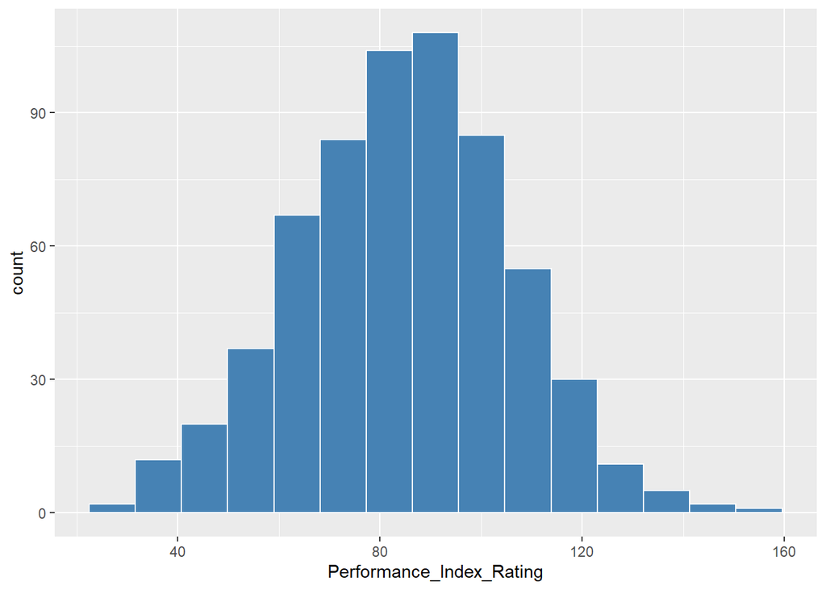

```r
#histogram of index ratings through seasons
ggplot(a,aes(Performance_Index_Rating))+
  geom_histogram(bins=15,color="white",fill="steelblue")
```

```r
#Most frequently played opponents
c<- a%>%
  count(Opposing_Team,sort=TRUE)
head(c)
```

```
##           Opposing_Team  n
## 1           Real Madrid 37
## 2    Olympiacos Piraeus 34
## 3           CSKA Moscow 33
## 4       Zalgiris Kaunas 26
## 5 Anadolu Efes Istanbul 24
## 6          FC Barcelona 21
```

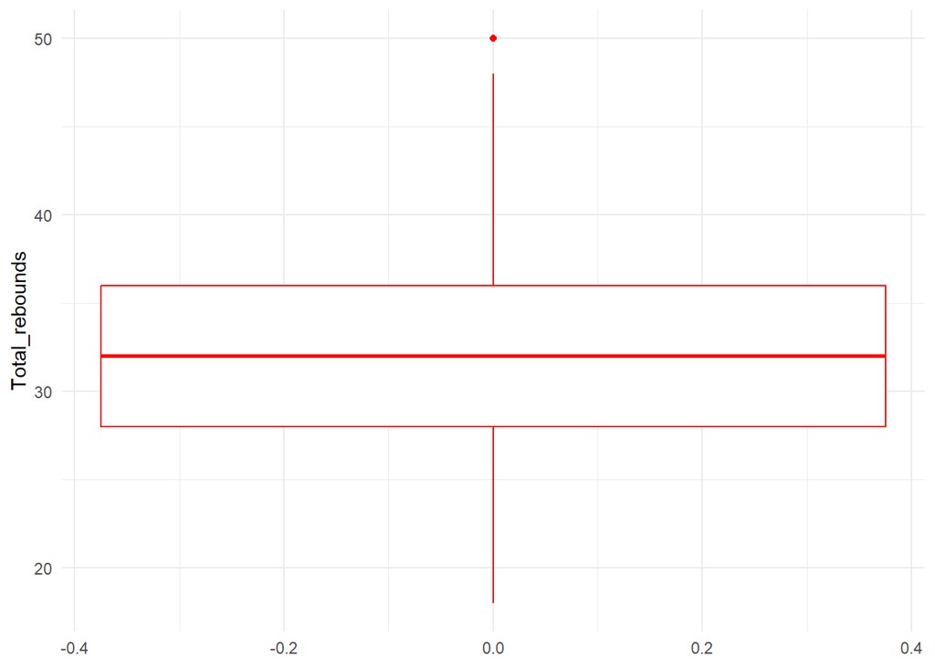

```r
#outliers for total_rebounds
ggplot(a,aes(y=Total_rebounds))+
  geom_boxplot(fill="white",color="red")+
  theme_minimal()
```

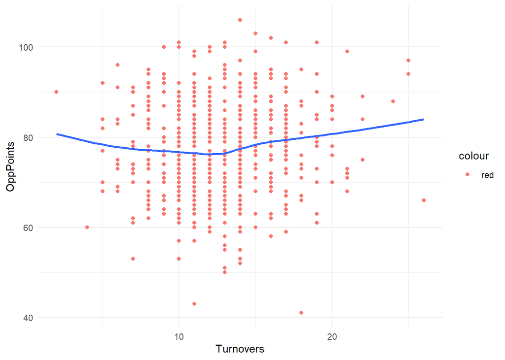

```r
#scatterplot with variables Turnovers and OppPoints

ggplot(a, aes(y = OppPoints, x = Turnovers)) +
  geom_point(aes( color = "red")) +
  geom_smooth(se = FALSE) +
  theme_minimal()
```

```r
#calculating outliers for turnovers

turnovers_clean <- a$Turnovers[!is.na(a$Turnovers)]

q1 <- quantile(turnovers_clean, 0.25)
q3 <- quantile(turnovers_clean, 0.75)
IQR <- q3 - q1

outliers <- turnovers_clean[
  turnovers_clean < q1 - 1.5*IQR | turnovers_clean > q3 + 1.5*IQR]
outliers
```

```
## [1] 26 24  2 25 25
```

```r
#win percentage based on location of game
win<-a%>%
  group_by(IsHome)%>%
  summarise(
    Wins=sum(Result=="W",na.rm=TRUE),
    Losses=sum(Result=="L",na.rm=TRUE),
    win_Percentage=round(Wins/(Wins+Losses)*100,1)

  )
win
```

```
## # A tibble: 2 × 4
##   IsHome  Wins Losses win_Percentage
##    <int> <int>  <int>          <dbl>
## 1      0   142    168           45.8
## 2      1   207    106           66.1
```

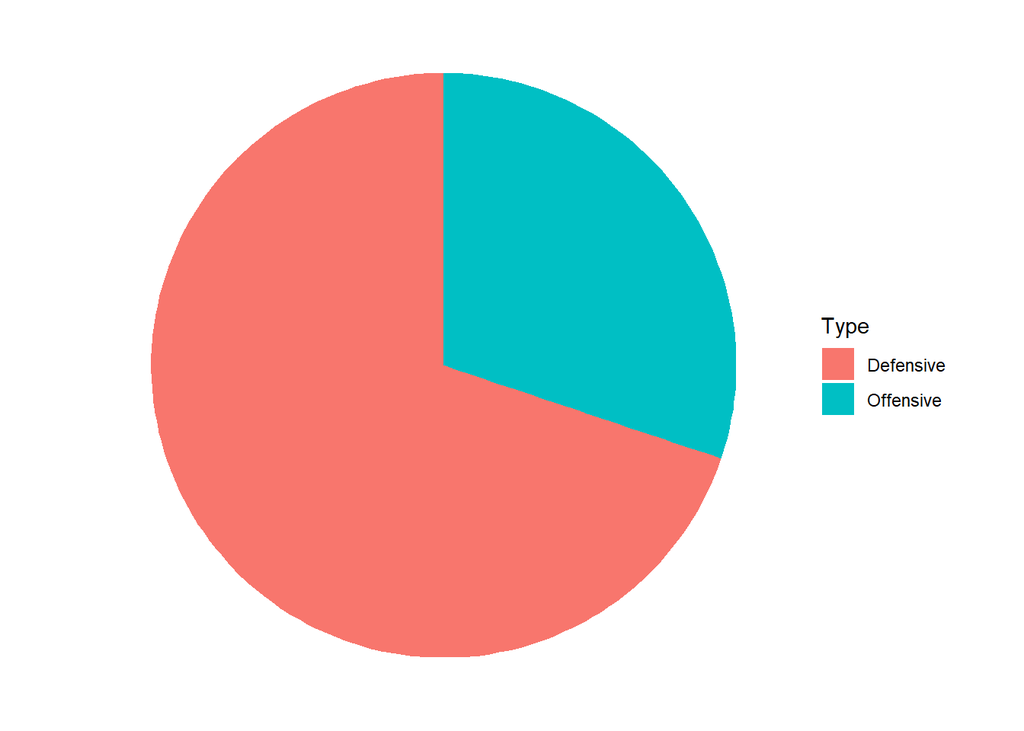

```r
#piechart of rebounds

rebounds<-data.frame(
Type<-c("Offensive","Defensive"),
Value<-c(sum(a$Offensive_rebounds,na.rm=TRUE),sum(a$Defensive_rebounds,na.rm=TRUE))
)

ggplot(rebounds,aes(x="",y=Value,fill=Type))+
  geom_col(width=1)+
  coord_polar(theta="y")+
  theme_void()
```

```r
#converting to character

a$IsHome <- ifelse(a$IsHome == "1", "Home", "Away")
a<-a%>%
  rename(Location=IsHome)
head(a)
```

```
##   Day Month Yearr         Opposing_Team Location Points
## 1  11   Oct  2001  Kinder London Towers     Home    107
## 2  18   Oct  2001              Zalgiris     Away     82
## 3  24   Oct  2001 Kinder Virtus Bologna     Away     60
## 4   1   Nov  2001        Union Olimpija     Home     75
## 5   8   Nov  2001        Opel Skyliners     Away     70
## 6  15   Nov  2001          FC Barcelona     Home     77
##   Performance_Index_Rating Two-point% Three-point% Free-throw%
## 1                      143      70.8%        36.8%       64.3%
## 2                       66      42.0%        52.6%       52.6%
## 3                       42      44.2%        25.0%       58.3%
## 4                       72      59.5%        14.3%       65.5%
## 5                       51      42.2%        33.3%       66.7%
## 6                       67      45.1%        26.7%       55.9%
##   Offensive_rebounds Defensive_rebounds Total_rebounds Assists Steals Blocks
## 1                 11                 27             38      21     16      1
## 2                 17                 20             37      15      7      1
## 3                 11                 23             34       5     10      1
## 4                 19                 17             36      15      8      1
## 5                 16                 18             34      13      1      3
## 6                 16                 14             30      14     14      1
##   Turnovers OppPoints Result
## 1        14        64      W
## 2        17        79      W
## 3        16        68      L
## 4        19        63      W
## 5        14        74      L
## 6        14        87      L
```

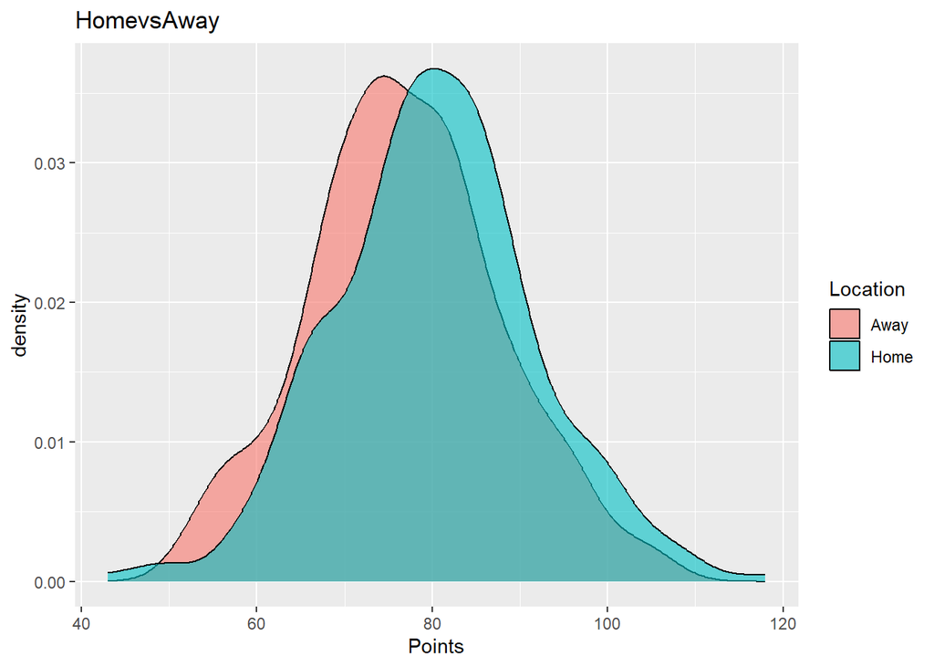

```r
ggplot(a,aes(x=Points,fill=Location))+
  geom_density(alpha=0.6)+
  labs(title="HomevsAway")
```

Main Statistical Methods

We now proceed to the central part of the project, which focuses on the application of statistical methods, including hypothesis testing, regression modelling, parameter estimation, and several additional analytical procedures relevant to this dataset.

```r
# converting to numeric
a <- a %>%
  mutate(across(c(`Three-point%`, `Two-point%`, `Free-throw%`),
                ~ as.numeric(gsub("%", "", .))))
```

Correlations

```r
cor(a$Offensive_rebounds,a$Points,use="complete.obs")
```

```
## [1] 0.04255767
```

```r
cor(a$Turnovers,a$OppPoints,use="complete.obs")
```

```
## [1] 0.08817229
```

```r
cor(a$Assists,a$Points,use="complete.obs")
```

```
## [1] 0.5711631
```

```r
ishome <- ifelse(a$Location == "Home", 1, 0)                         #corelations between some variables

cor(ishome,a$`Three-point%`,use="complete.obs")
```

```
## [1] 0.00650891
```

```r
a<-a%>%
  mutate(
    '+/-'=Points - OppPoints

  )                                                                #adding new variable +/-

cor(ishome,a$`+/-`,use="complete.obs")
```

```
## [1] 0.2447284
```

Statistical tests

```r
t.test(a$Points~a$Location,data=a)
```

```
##
##  Welch Two Sample t-test
##
## data:  a$Points by a$Location
## t = -3.735, df = 620.3, p-value = 0.000205
## alternative hypothesis: true difference in means between group Away and group Home is not equal to 0
## 95 percent confidence interval:
##  -5.134805 -1.595917
## sample estimates:
## mean in group Away mean in group Home
##           76.88065           80.24601
```

```r
t.test(a$OppPoints~a$Location,alternative="greater")
```

```
##
##  Welch Two Sample t-test
##
## data:  a$OppPoints by a$Location
## t = 4.0716, df = 620.82, p-value = 2.637e-05
## alternative hypothesis: true difference in means between group Away and group Home is greater than 0
## 95 percent confidence interval:
##  2.010313      Inf
## sample estimates:
## mean in group Away mean in group Home
##           79.26452           75.88818
```

```r
t.test(a$Total_rebounds~a$Location,alternative="less")
```

```
##
##  Welch Two Sample t-test
##
## data:  a$Total_rebounds by a$Location
## t = -1.6548, df = 621, p-value = 0.04924
## alternative hypothesis: true difference in means between group Away and group Home is less than 0
## 95 percent confidence interval:
##          -Inf -0.003420728
## sample estimates:
## mean in group Away mean in group Home
##           31.77097           32.52716
```

```r
chisq.test(a$Location, a$Result)
```

```
##
##  Pearson's Chi-squared test with Yates' continuity correction
##
## data:  a$Location and a$Result
## X-squared = 25.303, df = 1, p-value = 4.9e-07
```

```r
now <- a %>% filter(Opposing_Team
 %in% c("Real Madrid","Barcelona","Olympiacos","CSKA"))
fisher.test(now$Opposing_Team                                                 #working with categorical variables
, now$Result)
```

```
##
##  Fisher's Exact Test for Count Data
##
## data:  now$Opposing_Team and now$Result
## p-value = 1
## alternative hypothesis: two.sided
```

Linear Regression model

```r
#Model: Plus/minus depends on Points, Location, Free-throw percentage, and Total rebounds
a$Location <- factor(a$Location)

model <- lm(`+/-` ~ Points + Location + `Free-throw%` + Total_rebounds, data = a)
summary(model)
```

```
##
## Call:
## lm(formula = `+/-` ~ Points + Location + `Free-throw%` + Total_rebounds,
##     data = a)
##
## Residuals:
##     Min      1Q  Median      3Q     Max
## -28.098  -6.749  -0.007   6.729  34.858
##
## Coefficients:
##                 Estimate Std. Error t value Pr(>|t|)
## (Intercept)    -76.95009    3.62218 -21.244  < 2e-16 ***
## Points           0.74780    0.03567  20.963  < 2e-16 ***
## LocationHome     3.78348    0.77888   4.858 1.51e-06 ***
## `Free-throw%`   -0.01157    0.03178  -0.364    0.716
## Total_rebounds   0.56474    0.06794   8.313 5.95e-16 ***
## ---
## Signif. codes:  0 '***' 0.001 '**' 0.01 '*' 0.05 '.' 0.1 ' ' 1
##
## Residual standard error: 9.562 on 618 degrees of freedom
## Multiple R-squared:  0.5219, Adjusted R-squared:  0.5188
## F-statistic: 168.6 on 4 and 618 DF,  p-value: < 2.2e-16
```

```r
cat("R-squared:", summary(model)$r.squared, "\n")
```

```
## R-squared: 0.5218857
```

```r
cat("Adjusted R-squared:", summary(model)$adj.r.squared, "\n")
```

```
## Adjusted R-squared: 0.5187911
```

```r
rmse <- sqrt(mean(resid(model)^2))          #Root Mean Squared Error
cat("RMSE:", rmse, "\n")
```

```
## RMSE: 9.523923
```

```r
shapiro.test(resid(model))             #data is normally distributed or not
```

```
##
##  Shapiro-Wilk normality test
##
## data:  resid(model)
## W = 0.99875, p-value = 0.947
```

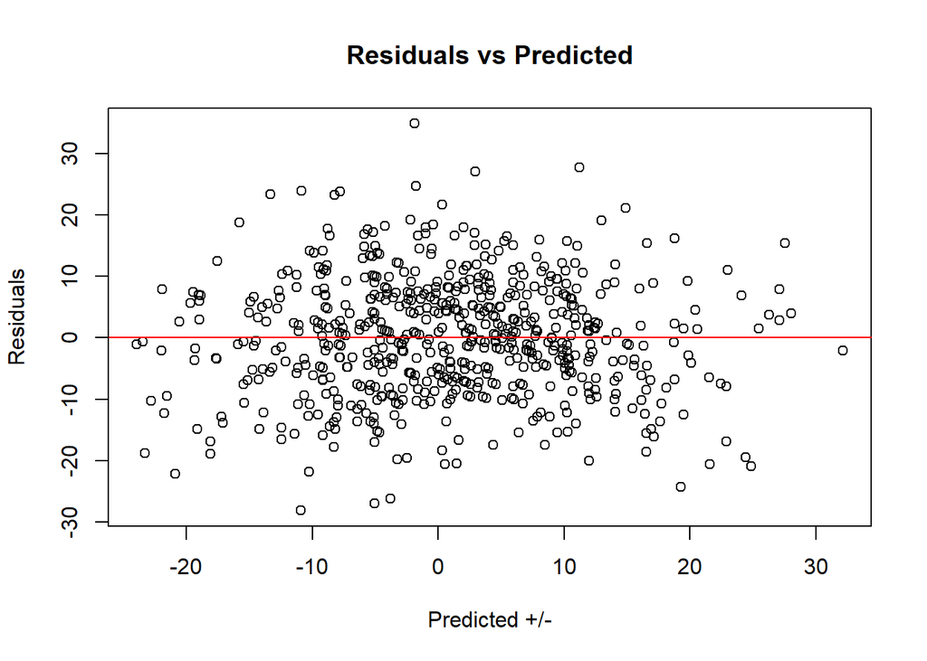

```r
#Homoscedasticity

plot(model$fitted.values, resid(model),
     xlab="Predicted +/-",
     ylab="Residuals",
     main="Residuals vs Predicted")
abline(h=0, col="red")
```

```r
library(car)
#multicollinearity
vif(model)
```

```
##         Points       Location  `Free-throw%` Total_rebounds
##       1.117798       1.033314       1.077196       1.023984
```

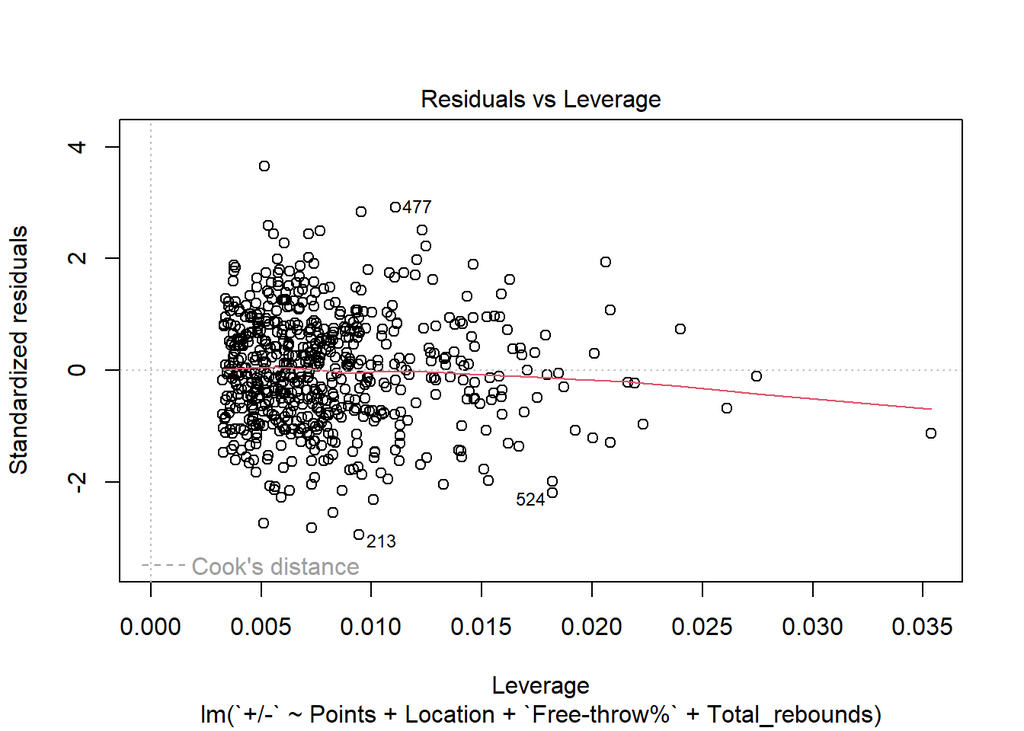

```r
plot(model, which=5)
```

```r
#for outliers
```

```r
outlier_index <- c(477, 213, 524)
model_no_outlier <- lm(`+/-` ~ Points + Location + `Free-throw%` + Total_rebounds,
                       data = a[-outlier_index, ])
summary(model_no_outlier)
```

```
##
## Call:
## lm(formula = `+/-` ~ Points + Location + `Free-throw%` + Total_rebounds,
##     data = a[-outlier_index, ])
##
## Residuals:
##     Min      1Q  Median      3Q     Max
## -27.109  -6.669   0.112   6.630  34.714
##
## Coefficients:
##                 Estimate Std. Error t value Pr(>|t|)
## (Intercept)    -76.26376    3.58182 -21.292  < 2e-16 ***
## Points           0.74779    0.03527  21.201  < 2e-16 ***
## LocationHome     3.84617    0.76831   5.006 7.27e-07 ***
## `Free-throw%`   -0.01893    0.03138  -0.603    0.546
## Total_rebounds   0.56053    0.06737   8.320 5.70e-16 ***
## ---
## Signif. codes:  0 '***' 0.001 '**' 0.01 '*' 0.05 '.' 0.1 ' ' 1
##
## Residual standard error: 9.414 on 615 degrees of freedom
## Multiple R-squared:  0.5266, Adjusted R-squared:  0.5235
## F-statistic:   171 on 4 and 615 DF,  p-value: < 2.2e-16
```

```r
#model without outliers
```

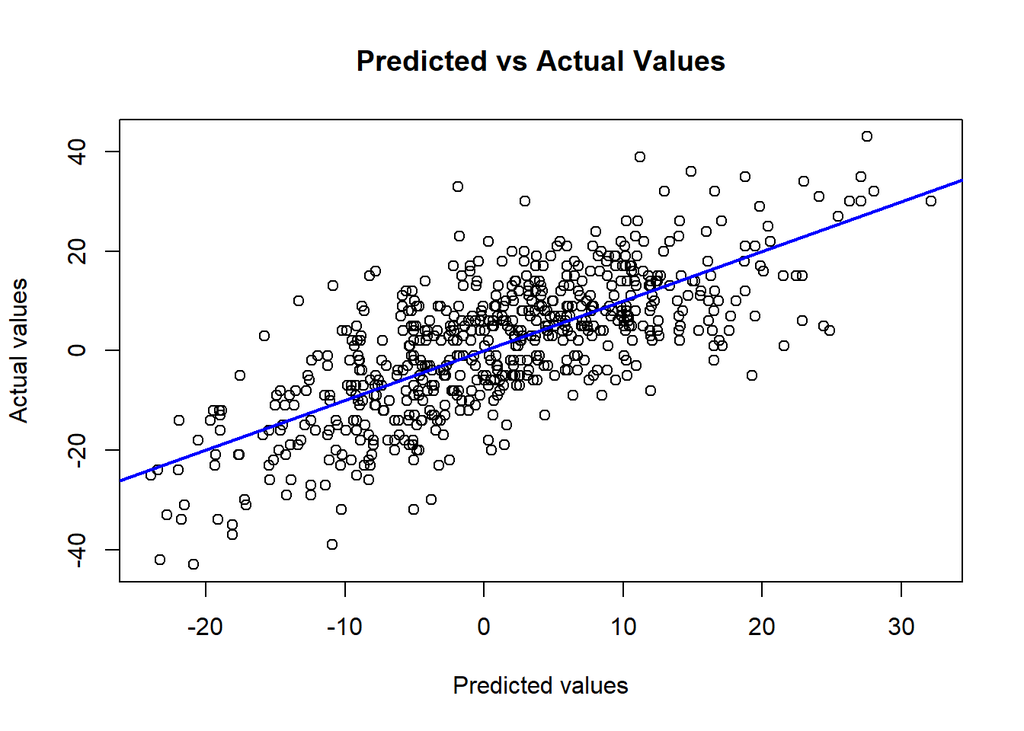

```r
plot(model$fitted.values, a$`+/-`,
     xlab="Predicted values",
     ylab="Actual values",
     main="Predicted vs Actual Values")
abline(a=0, b=1, col="blue", lwd=2)
```

Logistic regression model

```r
#logistic regression model that analyzes win
isWin<-ifelse(a$Result=="W",1,0)
model2<-glm(isWin~ a$Location+ a$Assists+ a$OppPoints, family = "binomial")
summary(model2)
```

```
##
## Call:
## glm(formula = isWin ~ a$Location + a$Assists + a$OppPoints, family = "binomial")
##
## Coefficients:
##                Estimate Std. Error z value Pr(>|z|)
## (Intercept)     7.57250    0.96481   7.849  4.2e-15 ***
## a$LocationHome  0.38769    0.20687   1.874   0.0609 .
## a$Assists       0.22745    0.02467   9.221  < 2e-16 ***
## a$OppPoints    -0.14107    0.01331 -10.602  < 2e-16 ***
## ---
## Signif. codes:  0 '***' 0.001 '**' 0.01 '*' 0.05 '.' 0.1 ' ' 1
##
## (Dispersion parameter for binomial family taken to be 1)
##
##     Null deviance: 854.61  on 622  degrees of freedom
## Residual deviance: 579.73  on 619  degrees of freedom
## AIC: 587.73
##
## Number of Fisher Scoring iterations: 5
```

```r
#how much more (or less) likely an event is to occur in one group compared to another
odds_ratios <- exp(coef(model2))
odds_ratios
```

```
##    (Intercept) a$LocationHome      a$Assists    a$OppPoints
##   1943.9922400      1.4735747      1.2554005      0.8684268
```

```r
#win predictor
new <- data.frame(Location = a$Location,
                       Assists = a$Assists,
                       OppPoints = a$OppPoints,Result=a$Result
                )

new$pred_win_prob <- predict(model2, newdata = new, type = "response")
head(new)
```

```
##   Location Assists OppPoints Result pred_win_prob
## 1     Home      21        64      W     0.9760637
## 2     Away      15        79      W     0.4599940
## 3     Away       5        68      L     0.2925313
## 4     Home      15        63      W     0.9230463
## 5     Away      13        74      L     0.5225058
## 6     Home      14        87      L     0.2444000
```

```r
#we can see how much predictor is accurate
new$pred_win_binary <- ifelse(new$pred_win_prob >= 0.5, 1, 0)

table(Predicted = new$pred_win_binary, Actual = new$Result)
```

```
##          Actual
## Predicted   L   W
##         0 197  65
##         1  77 284
```

```r
accuracy <- (197 + 284) / (197 + 65 + 77 + 284)
accuracy
```

```
## [1] 0.7720706
```

Scatterplots

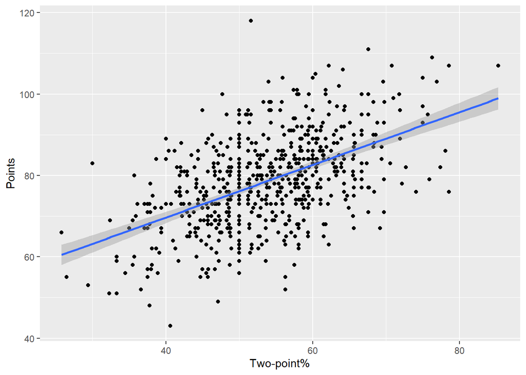

```r
#dependence of  two-point percentage on total points
ggplot(a,aes(`Two-point%`,Points))+
  geom_point()+
  geom_smooth(method="lm")
```

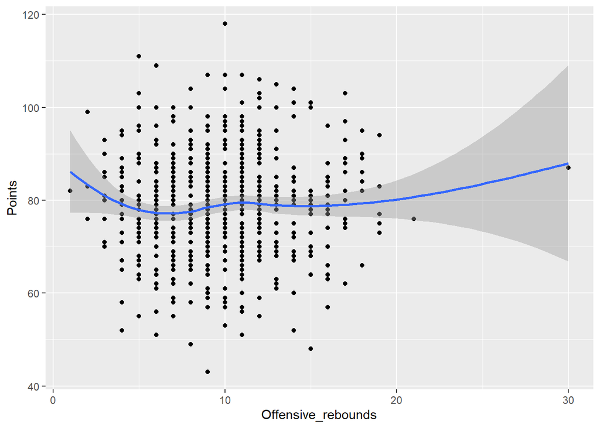

```r
#dependence of offensive rebounds on total points
ggplot(a,aes(Offensive_rebounds,Points))+
  geom_point()+
  geom_smooth(theme="lm")
```

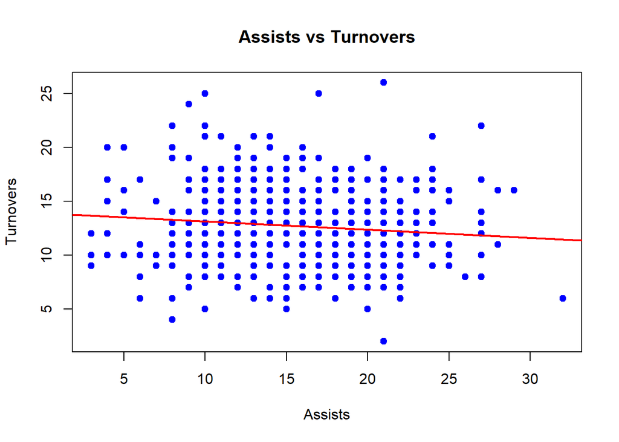

```r
#corelation between assists and turnovers in game
plot(a$Assists, a$Turnovers,
     xlab="Assists",
     ylab="Turnovers",
     main="Assists vs Turnovers",
     pch=19, col="blue")
abline(lm(Turnovers ~ Assists, data=a), col="red", lwd=2)
```

Anova tests

```r
a$Coach<-NA

a$Coach[1:19]<-"Mevlut Ongoren"
a$Coach[20:39]<-"Mevlut Ongoren"
a$Coach[40:100]<-"Ataman"
a$Coach[101]<-"Ataman"
a$Coach[102:116]<-"Ors"
a$Coach[116]<-""
a$Coach[116:163]<-""
a$Coach[116:163]<-"Tanjevic"
a$Coach[164:178]<-"Spahija"
a$Coach[179]<-"Spahija"
a$Coach[180:194]<-"Spahija"
a$Coach[195]<-"Spahija"
a$Coach[196:219]<-"Pianigiani"
a$Coach[220:435]<-"Obradovic"                          #first,manually added coaches for all years
a$Coach[436]<-"Obradovic"
a$Coach[437:473]<-"Kokoskov"
a$Coach[474:505]<-"Djordjevic"
a$Coach[505]<-""
a$Coach[505:543]<-"Itudis"
a$Coach[544:623]<-"Jasikevicius"

head(a)
```

```
##   Day Month Yearr         Opposing_Team Location Points
## 1  11   Oct  2001  Kinder London Towers     Home    107
## 2  18   Oct  2001              Zalgiris     Away     82
## 3  24   Oct  2001 Kinder Virtus Bologna     Away     60
## 4   1   Nov  2001        Union Olimpija     Home     75
## 5   8   Nov  2001        Opel Skyliners     Away     70
## 6  15   Nov  2001          FC Barcelona     Home     77
##   Performance_Index_Rating Two-point% Three-point% Free-throw%
## 1                      143       70.8         36.8        64.3
## 2                       66       42.0         52.6        52.6
## 3                       42       44.2         25.0        58.3
## 4                       72       59.5         14.3        65.5
## 5                       51       42.2         33.3        66.7
## 6                       67       45.1         26.7        55.9
##   Offensive_rebounds Defensive_rebounds Total_rebounds Assists Steals Blocks
## 1                 11                 27             38      21     16      1
## 2                 17                 20             37      15      7      1
## 3                 11                 23             34       5     10      1
## 4                 19                 17             36      15      8      1
## 5                 16                 18             34      13      1      3
## 6                 16                 14             30      14     14      1
##   Turnovers OppPoints Result +/-          Coach
## 1        14        64      W  43 Mevlut Ongoren
## 2        17        79      W   3 Mevlut Ongoren
## 3        16        68      L  -8 Mevlut Ongoren
## 4        19        63      W  12 Mevlut Ongoren
## 5        14        74      L  -4 Mevlut Ongoren
## 6        14        87      L -10 Mevlut Ongoren
```

```r
library(dplyr)
win_percentage<-a%>%
  group_by(Coach)%>%
  summarise(
    Games=n(),
    Wins=sum(Result=="W",na.rm=TRUE),
    Win_Percentage=round(Wins/Games*100,2)                      #win percentage for different coaches

  )
win_percentage
```

```
## # A tibble: 11 × 4
##    Coach          Games  Wins Win_Percentage
##    <chr>          <int> <int>          <dbl>
##  1 Ataman            62    25           40.3
##  2 Djordjevic        31    13           41.9
##  3 Itudis            39    21           53.8
##  4 Jasikevicius      80    51           63.8
##  5 Kokoskov          37    20           54.0
##  6 Mevlut Ongoren    39    22           56.4
##  7 Obradovic        217   148           68.2
##  8 Ors               14     5           35.7
##  9 Pianigiani        24     7           29.2
## 10 Spahija           32    18           56.2
## 11 Tanjevic          48    19           39.6
```

```r
#anova test with oppositing team points
sub<-a%>%
  filter(Coach %in% c("Obradovic","Djordjevic","Kokoskov","Jasikevicius"))
anova_result<-aov(OppPoints~Coach,data=sub)
summary(anova_result)
```

```
##              Df Sum Sq Mean Sq F value   Pr(>F)
## Coach         3   1906   635.5   5.769 0.000732 ***
## Residuals   361  39767   110.2
## ---
## Signif. codes:  0 '***' 0.001 '**' 0.01 '*' 0.05 '.' 0.1 ' ' 1
```

```r
#to determine which specific groups differ from each other
TukeyHSD(anova_result)
```

```
##   Tukey multiple comparisons of means
##     95% family-wise confidence level
##
## Fit: aov(formula = OppPoints ~ Coach, data = sub)
##
## $Coach
##                              diff        lwr       upr     p adj
## Jasikevicius-Djordjevic  6.504435  0.7733044 12.235567 0.0188642
## Kokoskov-Djordjevic      5.282476 -1.3134752 11.878427 0.1659527
## Obradovic-Djordjevic     1.548387 -3.6530077  6.749782 0.8686847
## Kokoskov-Jasikevicius   -1.221959 -6.6077786  4.163860 0.9363940
## Obradovic-Jasikevicius  -4.956048 -8.4993495 -1.412747 0.0019738
## Obradovic-Kokoskov      -3.734089 -8.5523555  1.084178 0.1897685
```

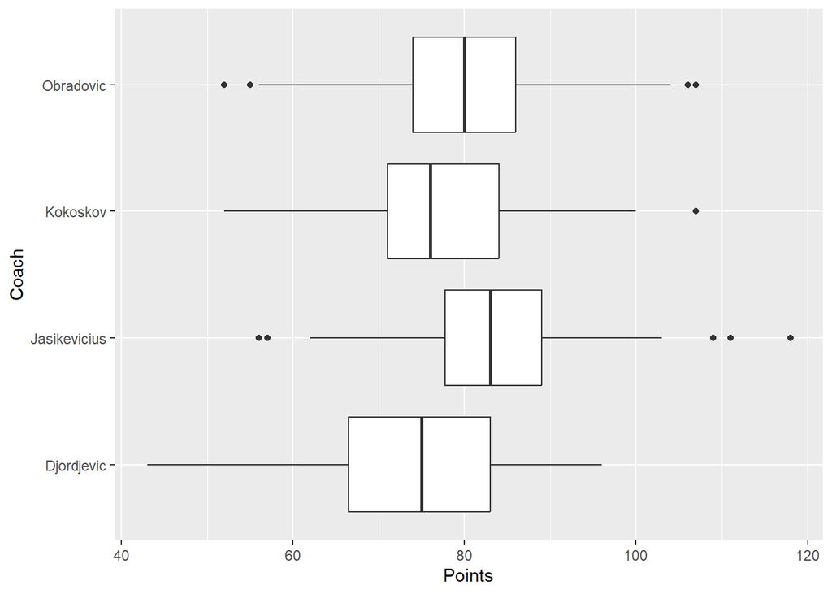

```r
#boxplot with points

ggplot(sub, aes(x = Coach, y = Points)) +
  geom_boxplot() +
  coord_flip()
```

```r
#anova test for assists
sub2<-a%>%
  filter(Coach %in% c("Obradovic","Djordjevic","Kokoskov","Jasikevicius"))
anova_result<-aov(Assists~Coach,data=sub2)
summary(anova_result)
```

```
##              Df Sum Sq Mean Sq F value Pr(>F)
## Coach         3     34   11.31   0.617  0.604
## Residuals   361   6621   18.34
```

```r
#tukey test
TukeyHSD(anova_result)
```

```
##   Tukey multiple comparisons of means
##     95% family-wise confidence level
##
## Fit: aov(formula = Assists ~ Coach, data = sub2)
##
## $Coach
##                                diff       lwr      upr     p adj
## Jasikevicius-Djordjevic -0.50927419 -2.847798 1.829250 0.9431904
## Kokoskov-Djordjevic      0.03836094 -2.653043 2.729765 0.9999821
## Obradovic-Djordjevic    -0.78341014 -2.905781 1.338961 0.7762904
## Kokoskov-Jasikevicius    0.54763514 -1.649988 2.745258 0.9178806
## Obradovic-Jasikevicius  -0.27413594 -1.719940 1.171668 0.9614323
## Obradovic-Kokoskov      -0.82177108 -2.787811 1.144269 0.7026935
```

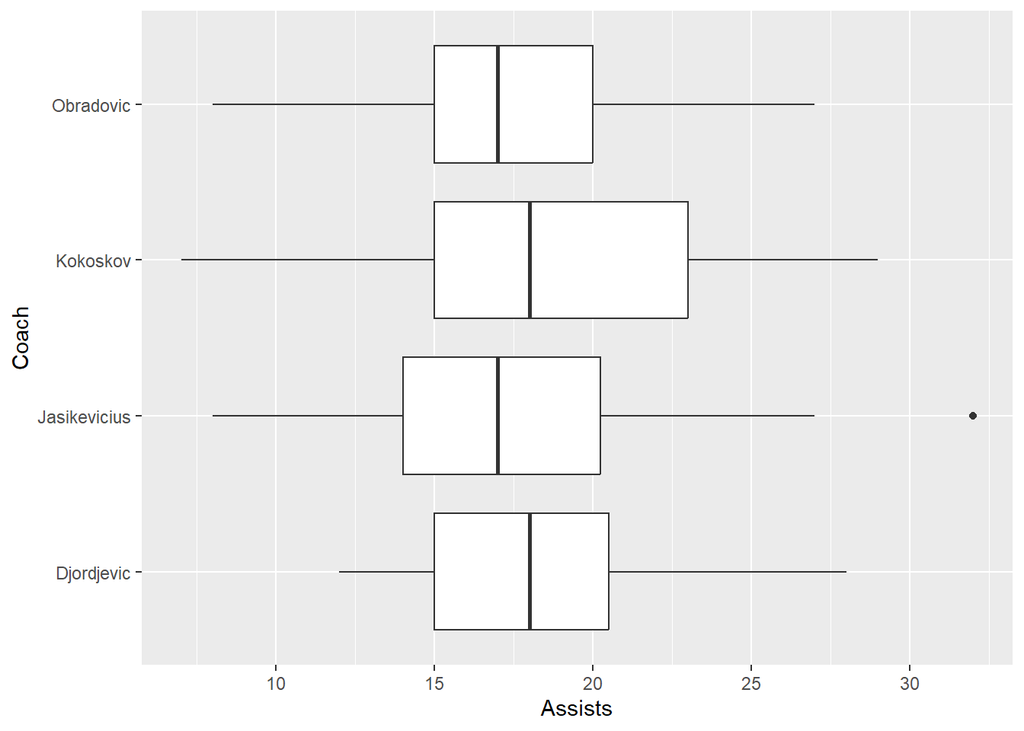

```r
#boxplot with assists

ggplot(sub, aes(x = Coach, y = Assists)) +
  geom_boxplot() +
  coord_flip()
```

Visualisation

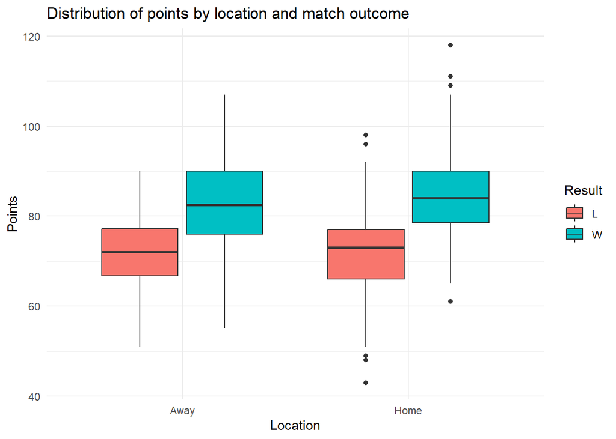

```r
ggplot(a, aes(x = Location, y = Points, fill = Result)) +
  geom_boxplot() +
  labs(title = "Distribution of points by location and match outcome",
       y = "Points",
       x = "Location") +
  theme_minimal()
```

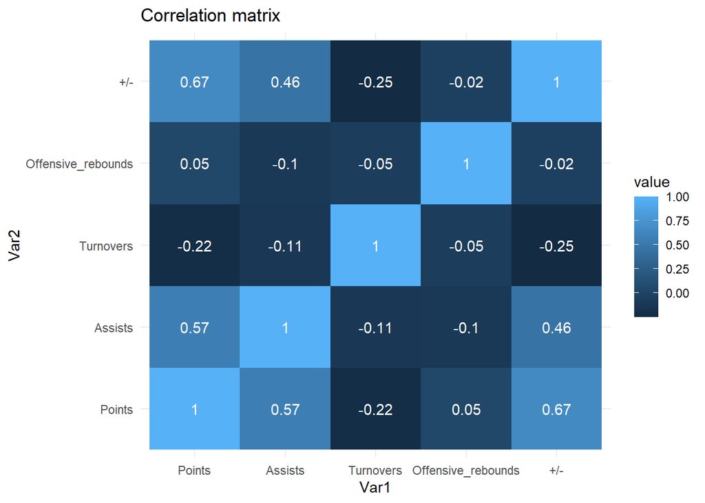

```r
library(reshape2)
corr_mat <- cor(a[,c("Points","Assists","Turnovers","Offensive_rebounds","+/-")], use="complete.obs")
melted <- melt(corr_mat)
ggplot(melted, aes(Var1, Var2, fill = value)) +
  geom_tile() +
  geom_text(aes(label=round(value,2)), color="white") +
  theme_minimal() +
  labs(title="Correlation matrix")
```

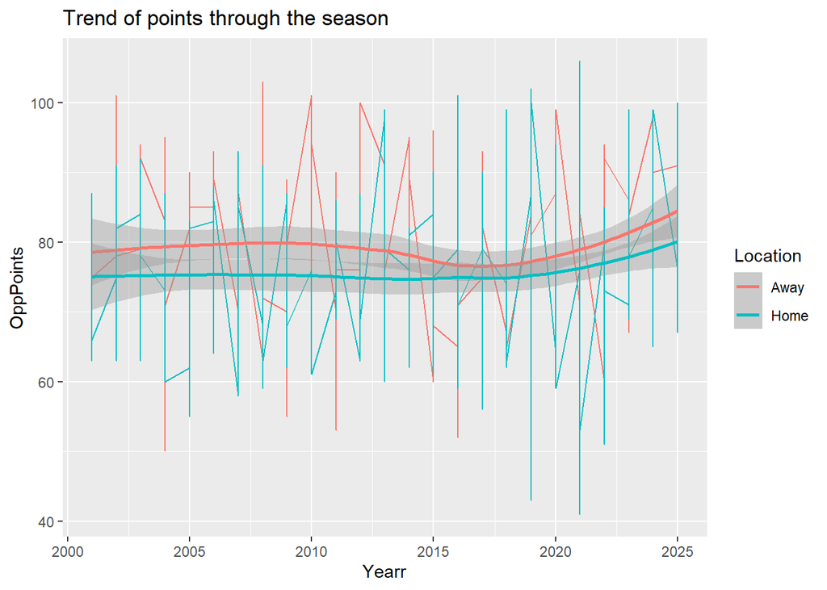

```r
ggplot(a, aes(x = Yearr, y = OppPoints, color = Location)) +
  geom_line() +
  geom_smooth(method="loess") +
  labs(title="Trend of points through the season", x="Yearr", y="OppPoints")
```

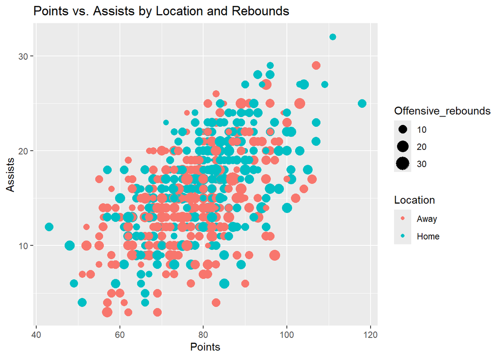

```r
ggplot(a, aes(x = Points, y = Assists, color = Location, size = Offensive_rebounds)) +
  geom_point() +
  labs(title = "Points vs. Assists by Location and Rebounds")
```

Interpretation of results

This section presents the analysis results, focusing on key patterns and insights revealed by the data. The findings highlight relationships between different performance metrics and their impact on game outcomes.

Correlation analysis

Regarding correlation:

- We observe that the correlation between offensive rebounds and points scored is significantly small, as well as between turnovers and points conceded.
- There is a moderate positive correlation between assists and total points.
- The correlation between three-point percentage and game location is very weak.
- Slightly stronger, but still weak, is the correlation between +/- and game location.

We conclude that assists are a fairly important parameter for points scored, which implies the significance of offensive creation, in terms of structured plays rather than one-on-one actions. Turnovers are not strongly related to points conceded, which is interesting. This likely means that turnovers did not result in fast breaks or easy points, but rather that the team was able to quickly return to a defensive stance after a mistake.

Tests

We proceeded with statistical testing, specifically employing the t-test, which provides various outputs, including the confidence interval, as well as the chi-square test, which assesses independence between variables. As is well known, the key component of the t-test is the p-value, which determines whether we reject or fail to reject the null hypothesis. We examined the following:

Chisq.test/Fisher:

- We tested the independence between game location and match outcome, and obtained a low p-value, indicating that these two variables are not independent. The location of the game has a considerable impact on the result.
- The high p-value indicates that we do not have sufficient evidence to conclude that match outcome depends on the opponent within this sample. However, on a larger sample, it does not matter which specific team is played against, as players approach their performance professionally.

Linear model

Linear model for +/-:

- We selected the dependent variable +/- and examined how, and whether, the independent variables—points, game location, free throws, and rebounds—affect it.
- We observe that points, rebounds, and game location are statistically significant, whereas free throws practically have no effect on +/-.
- Points are the strongest predictor, which is logical since +/- represents the difference in final points and is therefore closely related.
- The coefficient of determination R² is approximately 0.52, indicating that the model explains about 52% of the total variability in the point difference, while the adjusted R² (≈ 0.52) confirms that the inclusion of additional predictors does not overestimate the explanation. The Root Mean Squared Error (RMSE ≈ 9.52) shows that the average prediction of +/- differs from the actual result by about 9.5 points, representing a solid level of accuracy considering the variability inherent in sports games.
- We used the Shapiro test to assess the normality of the residuals.
- The next aspect is homoscedasticity. We observe that the residuals are distributed roughly evenly around zero, suggesting that the homoscedasticity assumption is not severely violated. There is a slight change in variance at extreme predicted values, but it does not compromise the interpretation of the model. -We checked for multicollinearity using the VIF function and observed that the values are approximately equal to one.
- In the next plot, we examined Residuals vs. Leverage and identified some outliers.
- We then removed these values and rebuilt the model to see if there were any significant differences. The coefficients remained similar, leading us to conclude that removing the outliers resulted in a slightly more stable model, but the original model is very similar and exhibits comparable stability.
- Next, we created a scatterplot of Predicted vs. Actual values.
- We can observe that most points lie close to the line, indicating that the model generally predicts +/- well. Additionally, there is no obvious pattern of curvature, suggesting that the model is indeed appropriate.

Logistic Regression Model

The next step is the logistic regression model:

- We aim to model wins in relation to the variables: game location, assists, and opponent points.
- We observe that opponent points and assists are statistically highly significant, whereas game location is not particularly significant. In the previous linear regression, we saw that +/- depends on location, but here in the logistic model, the outcome does not depend on location. Why does this make sense? It is logical because we are dealing with a binary variable, and the model only considers whether a win occurred, not by how much. In the linear regression, we analyzed the magnitude of the point difference, which reflects how large or small a win is. Here, when other predictors such as assists and opponent points are included, location alone is no longer as significant relative to them.
- The odds ratio (OR) indicates how the odds of an event (in this case, a win) change when a predictor increases by one unit, holding all other factors constant.
- We conclude that playing at home increases the odds of winning by approximately 47%, while each additional assist increases the odds by about 25%. On the other hand, each additional opponent point decreases the odds by roughly 13%.
- Next, we created a predictor based on this model, which provides the probability of a win. We then tested it on several examples using the head function. Overall, we compiled the results into a table: when the model predicted a loss, there were 197 losses and 65 wins; when it predicted a win, there were 284 wins and 77 losses. Using the accuracy metric, we observe that the model achieves an accuracy of 77%.

Discussion

■ The analyses demonstrate that points scored and assists are the most influential factors for both point differential (+/-) and match outcomes. While home-court advantage affects scoring, its significance diminishes when other variables such as assists and opponent points are considered. ■ Rebounds and turnovers contribute moderately, highlighting the role of defensive positioning and game recovery. Overall, the models provide reliable predictions and offer valuable insights into team performance and strategic decision-making in EuroLeague basketball.

Limitations

■ Although the analysis provides valuable insights, several limitations should be taken into account:

- Correlation analysis does not imply causation
- Lack of control variables
- Limited range of available metrics
- Data format does not capture contextual information
- Coaching comparisons may be influenced by differences in playing style and league trends across different eras
- No temporal dynamics included in the analysis

Conclusion

■ The analysis of Fenerbahçe’s performance reveals several clear patterns in the statistical indicators. The correlation structure shows that most basic variables exhibit very weak relationships with one another, suggesting that game outcomes cannot be explained through simple linear associations. Offensive rebounds demonstrate minimal connection with total points scored, while the relationship between turnovers and points conceded is similarly weak. This indicates that second-chance opportunities and turnovers are not among the primary statistical predictors of game results within the available dataset.

■ Overall, the results indicate that no single statistical category alone is sufficient to fully explain the outcome of games. However, multiple metrics considered together can provide valuable insights into team play patterns. Within this analysis, certain relationships, such as the connection between assists and points scored, can highlight offensive tendencies and efficiency, while other statistics complement the picture by offering additional information about playing style. Although the basic available metrics do not point to a single dominant factor, they allow for the identification of meaningful trends and provide a solid foundation for deeper analytical understanding of team performance.